# HDT7-SMV

Mariana David, Alejandra Guzman, Jorge Caballeros

21/4/2023

## Analisis

En esta HDT se trabajara con el modelo svm de la librería e1071 y varias otras funciónes que requieren transformaciónes de data. Primero se nos pide que se genere una variable que defina entre economico, caro e intermedio que ya se había hecho en hojas de trabajo pasadas. Dado que los datos máximos atípicos afectan considerablemente a una predicción, no se categorizan entre ninguna de las tres clasificaciónes por lo que se producen valores NA en nuestra variable tipoDeCasa. Para solventar este problema, eliminaremos las filas que tienen NA en la variable tipoDeCasa. Tambien es importante que las variables cuantitativas no tengan NA en ellas, por lo que las cambiamos por 0 tomando en cuenta lo que representa cada variable.

```
## 'data.frame':    1436 obs. of  82 variables:
##  $ Id           : int  1 2 3 4 5 6 7 8 9 10 ...
##  $ MSSubClass   : int  60 20 60 70 60 50 20 60 50 190 ...
##  $ MSZoning     : Factor w/ 5 levels "C (all)","FV",..: 4 4 4 4 4 4 4 4 5 4 ...
##  $ LotFrontage  : num  65 80 68 60 84 85 75 0 51 50 ...
##  $ LotArea      : int  8450 9600 11250 9550 14260 14115 10084 10382 6120 7420 ...
##  $ Street       : Factor w/ 2 levels "Grvl","Pave": 2 2 2 2 2 2 2 2 2 2 ...
##  $ Alley        : Factor w/ 3 levels "0","Grvl","Pave": 1 1 1 1 1 1 1 1 1 1 ...
##  $ LotShape     : Factor w/ 4 levels "IR1","IR2","IR3",..: 4 4 1 1 1 1 4 1 4 4 ...
##  $ LandContour  : Factor w/ 4 levels "Bnk","HLS","Low",..: 4 4 4 4 4 4 4 4 4 4 ...
##  $ Utilities    : Factor w/ 2 levels "AllPub","NoSeWa": 1 1 1 1 1 1 1 1 1 1 ...
##  $ LotConfig    : Factor w/ 5 levels "Corner","CulDSac",..: 5 3 5 1 3 5 5 1 5 1 ...
##  $ LandSlope    : Factor w/ 3 levels "Gtl","Mod","Sev": 1 1 1 1 1 1 1 1 1 1 ...
##  $ Neighborhood : Factor w/ 25 levels "Blmngtn","Blueste",..: 6 25 6 7 14 12 21 17 18 4 ...
##  $ Condition1   : Factor w/ 9 levels "Artery","Feedr",..: 3 2 3 3 3 3 3 5 1 1 ...
```

[output cut: 68 more lines]

Vamos a hacer un analisis de correlación, para descartar las variables cuantitativas que tienen mucha correlación entre ellas y así facilitar la fase del modelo. Para esto, se decidió separar la base de datos en dos conjuntos de datos, ya que son muchas columnas. La primer matriz hace referencia al conjunto1, la segunda hace referencia al conjunto2, la tercera es la matriz de correlación entre conjunto1 y conjunto2. Por último tenemos una tabla comparativa que nos permite ver con mayor facilidad la correlación entre la variable tipoDeCasa y todas las demás.

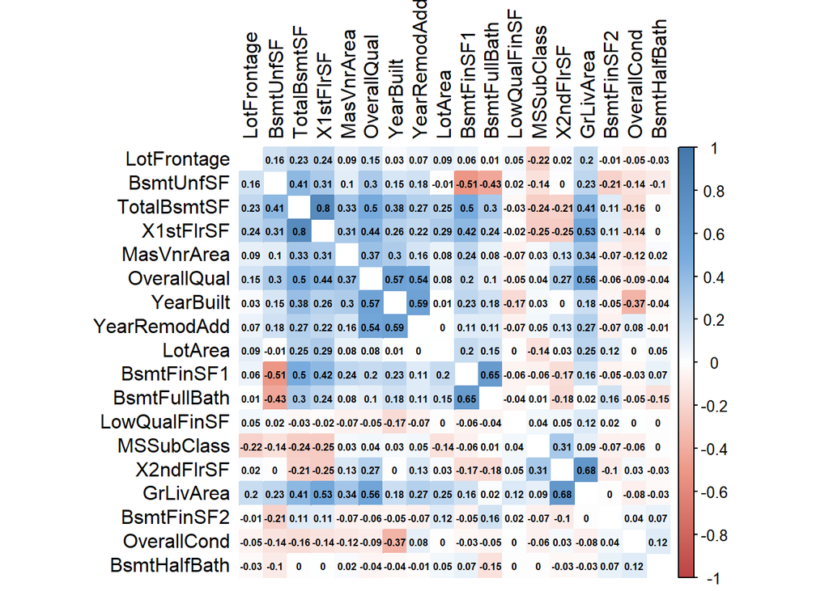

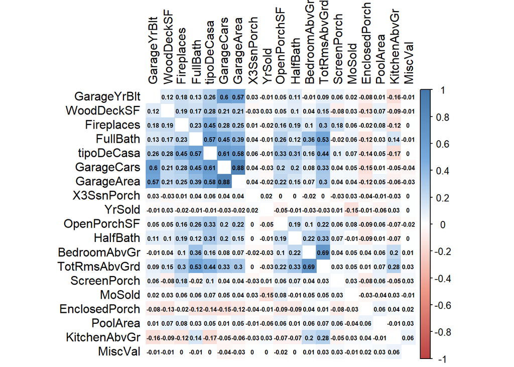

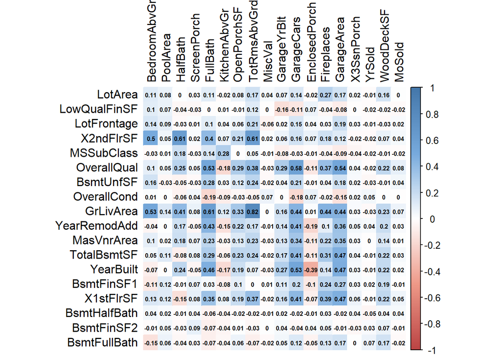

```
##                       [,1]
## LotFrontage    0.124781325
## LotArea        0.219555016
## OverallQual    0.738892019
## OverallCond   -0.095483076
## YearBuilt      0.565329689
## YearRemodAdd   0.544774124
## MasVnrArea     0.344254632
## BsmtFinSF1     0.276950433
## BsmtFinSF2     0.012463641
## BsmtUnfSF      0.208466092
## TotalBsmtSF    0.513208477
## X1stFlrSF      0.496997346
## X2ndFlrSF      0.297500739
## LowQualFinSF  -0.068654379
## GrLivArea      0.622251690
## BsmtFullBath   0.189408729
## BsmtHalfBath  -0.035329884
## FullBath       0.574967912
## HalfBath       0.307309514
## BedroomAbvGr   0.157624456
## KitchenAbvGr  -0.167361574
## TotRmsAbvGrd   0.441616356
## Fireplaces     0.454122445
## GarageYrBlt    0.262710019
## GarageCars     0.610605411
## GarageArea     0.575708954
## WoodDeckSF     0.281222474
## OpenPorchSF    0.326152417
## EnclosedPorch -0.138763225
## X3SsnPorch     0.059689959
## ScreenPorch    0.099859557
## PoolArea       0.051525222
## MiscVal       -0.001375927
## MoSold         0.070906122
## YrSold        -0.012373046
## tipoDeCasa     1.000000000
```

Tambien sabemos que las variables que tienen una correlación entre ellas mayor a 0.6 son:

- TotalBsmtSF con X1stFlrSF
- BsmtFinSF1 con BsmtFullBath
- X2ndFlrSF con GrLivArea con HalfBath con TotRmsAbvGrd
- FullBath con GrLivArea
- GarageCars con GarageArea
- BedroomAbvGr con TotRmsAbvGrd

## Modelo de SVM

Uno de los principales requisitos es que los “factors” sean de al menos 2 niveles para poder ser ingresados a la función de svm. En totala se realizarán nueve modelos de los cuales 3 son lineales, 3 son radiales y 3 son polinomiales. Se cambiaron factores como costo, gamma, degree y coef0 para tener diferentes combinaciones que nos dieran diferentes resultados y en base a cada combinación, se buscaron numeros que promovieran una mayor precisión en la predicción.

```
##
## Call:
## svm(formula = tipoDeCasa ~ ., data = train, type = "C-classification",
##     cost = 2^5, kernel = "linear")
##
##
## Parameters:
##    SVM-Type:  C-classification
##  SVM-Kernel:  linear
##        cost:  32
##
## Number of Support Vectors:  337
##
##  ( 91 153 93 )
##
##
## Number of Classes:  3
##
## Levels:
##  1 2 3
```

```
##
## Call:
## svm(formula = tipoDeCasa ~ ., data = train, type = "C-classification",
##     gamma = 0.005, kernel = "radial")
##
##
## Parameters:
##    SVM-Type:  C-classification
##  SVM-Kernel:  radial
##        cost:  1
##
## Number of Support Vectors:  641
##
##  ( 164 305 172 )
##
##
## Number of Classes:  3
##
## Levels:
##  1 2 3
```

```
##
## Call:
## svm(formula = tipoDeCasa ~ ., data = train, type = "C-classification",
##     gamma = 1, kernel = "polynomial", coef0 = 1, degree = 8)
##
##
## Parameters:
##    SVM-Type:  C-classification
##  SVM-Kernel:  polynomial
##        cost:  1
##      degree:  8
##      coef.0:  1
##
## Number of Support Vectors:  826
##
##  ( 175 325 326 )
##
##
## Number of Classes:  3
##
## Levels:
##  1 2 3
```

## Matrices de confusión:

Para esta parte hay que asegurar que ambos factores que se van a comparar que en este caso es predicción y test, es requerido que sean factores del mismo nivel, por lo que no puede haber ninún tipo de fallo en el formato de ambos factores. A continuación se pueden ver los resultados de los 9 modelos que se realizaron.

#### - Matrices de confusión de modelos lineales

```
## Confusion Matrix and Statistics
##
##           Reference
## Prediction   1   2   3
##          1 128  29   1
##          2  24 104  22
##          3   1  33  89
##
## Overall Statistics
##
##                Accuracy : 0.7448
##                  95% CI : (0.7009, 0.7853)
##     No Information Rate : 0.3852
##     P-Value [Acc > NIR] : <2e-16
##
##                   Kappa : 0.6143
##
##  Mcnemar's Test P-Value : 0.4451
##
## Statistics by Class:
##
##                      Class: 1 Class: 2 Class: 3
## Sensitivity            0.8366   0.6265   0.7946
## Specificity            0.8921   0.8264   0.8934
## Pos Pred Value         0.8101   0.6933   0.7236
## Neg Pred Value         0.9084   0.7794   0.9253
## Prevalence             0.3550   0.3852   0.2599
## Detection Rate         0.2970   0.2413   0.2065
## Detection Prevalence   0.3666   0.3480   0.2854
## Balanced Accuracy      0.8643   0.7265   0.8440
```

```
## Confusion Matrix and Statistics
##
##           Reference
## Prediction   1   2   3
##          1 140  18   0
##          2  22 106  22
##          3   1  24  98
##
## Overall Statistics
##
##                Accuracy : 0.7981
##                  95% CI : (0.7571, 0.835)
##     No Information Rate : 0.3782
##     P-Value [Acc > NIR] : <2e-16
##
##                   Kappa : 0.6953
##
##  Mcnemar's Test P-Value : 0.6853
##
## Statistics by Class:
##
##                      Class: 1 Class: 2 Class: 3
## Sensitivity            0.8589   0.7162   0.8167
## Specificity            0.9328   0.8445   0.9196
## Pos Pred Value         0.8861   0.7067   0.7967
## Neg Pred Value         0.9158   0.8505   0.9286
## Prevalence             0.3782   0.3434   0.2784
## Detection Rate         0.3248   0.2459   0.2274
## Detection Prevalence   0.3666   0.3480   0.2854
## Balanced Accuracy      0.8959   0.7804   0.8681
```

```
## Confusion Matrix and Statistics
##
##           Reference
## Prediction   1   2   3
##          1 147  11   0
##          2  19 115  16
##          3   0  23 100
##
## Overall Statistics
##
##                Accuracy : 0.8399
##                  95% CI : (0.8018, 0.8733)
##     No Information Rate : 0.3852
##     P-Value [Acc > NIR] : < 2.2e-16
##
##                   Kappa : 0.7581
##
##  Mcnemar's Test P-Value : NA
##
## Statistics by Class:
##
##                      Class: 1 Class: 2 Class: 3
## Sensitivity            0.8855   0.7718   0.8621
## Specificity            0.9585   0.8759   0.9270
## Pos Pred Value         0.9304   0.7667   0.8130
## Neg Pred Value         0.9304   0.8790   0.9481
## Prevalence             0.3852   0.3457   0.2691
## Detection Rate         0.3411   0.2668   0.2320
## Detection Prevalence   0.3666   0.3480   0.2854
## Balanced Accuracy      0.9220   0.8238   0.8945
```

#### - Matrices de confusión de modelos radiales

```
## Confusion Matrix and Statistics
##
##           Reference
## Prediction   1   2   3
##          1 149   9   0
##          2  23 117  10
##          3   1  32  90
##
## Overall Statistics
##
##                Accuracy : 0.826
##                  95% CI : (0.7868, 0.8606)
##     No Information Rate : 0.4014
##     P-Value [Acc > NIR] : < 2.2e-16
##
##                   Kappa : 0.736
##
##  Mcnemar's Test P-Value : 0.0003231
##
## Statistics by Class:
##
##                      Class: 1 Class: 2 Class: 3
## Sensitivity            0.8613   0.7405   0.9000
## Specificity            0.9651   0.8791   0.9003
## Pos Pred Value         0.9430   0.7800   0.7317
## Neg Pred Value         0.9121   0.8541   0.9675
## Prevalence             0.4014   0.3666   0.2320
## Detection Rate         0.3457   0.2715   0.2088
## Detection Prevalence   0.3666   0.3480   0.2854
## Balanced Accuracy      0.9132   0.8098   0.9002
```

```
## Confusion Matrix and Statistics
##
##           Reference
## Prediction   1   2   3
##          1 143  15   0
##          2  23 119   8
##          3   2  37  84
##
## Overall Statistics
##
##                Accuracy : 0.8028
##                  95% CI : (0.762, 0.8393)
##     No Information Rate : 0.3968
##     P-Value [Acc > NIR] : < 2.2e-16
##
##                   Kappa : 0.7003
##
##  Mcnemar's Test P-Value : 5.455e-05
##
## Statistics by Class:
##
##                      Class: 1 Class: 2 Class: 3
## Sensitivity            0.8512   0.6959   0.9130
## Specificity            0.9430   0.8808   0.8850
## Pos Pred Value         0.9051   0.7933   0.6829
## Neg Pred Value         0.9084   0.8149   0.9740
## Prevalence             0.3898   0.3968   0.2135
## Detection Rate         0.3318   0.2761   0.1949
## Detection Prevalence   0.3666   0.3480   0.2854
## Balanced Accuracy      0.8971   0.7883   0.8990
```

```
## Confusion Matrix and Statistics
##
##           Reference
## Prediction   1   2   3
##          1 145  13   0
##          2  19 122   9
##          3   0  31  92
##
## Overall Statistics
##
##                Accuracy : 0.8329
##                  95% CI : (0.7943, 0.8669)
##     No Information Rate : 0.3852
##     P-Value [Acc > NIR] : < 2.2e-16
##
##                   Kappa : 0.7467
##
##  Mcnemar's Test P-Value : NA
##
## Statistics by Class:
##
##                      Class: 1 Class: 2 Class: 3
## Sensitivity            0.8841   0.7349   0.9109
## Specificity            0.9513   0.8943   0.9061
## Pos Pred Value         0.9177   0.8133   0.7480
## Neg Pred Value         0.9304   0.8434   0.9708
## Prevalence             0.3805   0.3852   0.2343
## Detection Rate         0.3364   0.2831   0.2135
## Detection Prevalence   0.3666   0.3480   0.2854
## Balanced Accuracy      0.9177   0.8146   0.9085
```

#### - Matrices de confusión de modelos polinomiales

```
## Confusion Matrix and Statistics
##
##           Reference
## Prediction   1   2   3
##          1 145  13   0
##          2  23 120   7
##          3   1  46  76
##
## Overall Statistics
##
##                Accuracy : 0.7912
##                  95% CI : (0.7497, 0.8286)
##     No Information Rate : 0.4153
##     P-Value [Acc > NIR] : < 2.2e-16
##
##                   Kappa : 0.682
##
##  Mcnemar's Test P-Value : 4.154e-07
##
## Statistics by Class:
##
##                      Class: 1 Class: 2 Class: 3
## Sensitivity            0.8580   0.6704   0.9157
## Specificity            0.9504   0.8810   0.8649
## Pos Pred Value         0.9177   0.8000   0.6179
## Neg Pred Value         0.9121   0.7900   0.9773
## Prevalence             0.3921   0.4153   0.1926
## Detection Rate         0.3364   0.2784   0.1763
## Detection Prevalence   0.3666   0.3480   0.2854
## Balanced Accuracy      0.9042   0.7757   0.8903
```

```
## Confusion Matrix and Statistics
##
##           Reference
## Prediction   1   2   3
##          1 143  15   0
##          2  23 108  19
##          3   0  23 100
##
## Overall Statistics
##
##                Accuracy : 0.8144
##                  95% CI : (0.7744, 0.85)
##     No Information Rate : 0.3852
##     P-Value [Acc > NIR] : < 2.2e-16
##
##                   Kappa : 0.7197
##
##  Mcnemar's Test P-Value : NA
##
## Statistics by Class:
##
##                      Class: 1 Class: 2 Class: 3
## Sensitivity            0.8614   0.7397   0.8403
## Specificity            0.9434   0.8526   0.9263
## Pos Pred Value         0.9051   0.7200   0.8130
## Neg Pred Value         0.9158   0.8648   0.9383
## Prevalence             0.3852   0.3387   0.2761
## Detection Rate         0.3318   0.2506   0.2320
## Detection Prevalence   0.3666   0.3480   0.2854
## Balanced Accuracy      0.9024   0.7962   0.8833
```

```
## Confusion Matrix and Statistics
##
##           Reference
## Prediction   1   2   3
##          1 140  18   0
##          2  21 111  18
##          3   0  20 103
##
## Overall Statistics
##
##                Accuracy : 0.8213
##                  95% CI : (0.7819, 0.8564)
##     No Information Rate : 0.3735
##     P-Value [Acc > NIR] : < 2.2e-16
##
##                   Kappa : 0.7304
##
##  Mcnemar's Test P-Value : NA
##
## Statistics by Class:
##
##                      Class: 1 Class: 2 Class: 3
## Sensitivity            0.8696   0.7450   0.8512
## Specificity            0.9333   0.8617   0.9355
## Pos Pred Value         0.8861   0.7400   0.8374
## Neg Pred Value         0.9231   0.8648   0.9416
## Prevalence             0.3735   0.3457   0.2807
## Detection Rate         0.3248   0.2575   0.2390
## Detection Prevalence   0.3666   0.3480   0.2854
## Balanced Accuracy      0.9014   0.8033   0.8934
```

#7 Evaluación del primer modelo, para saber si tiene sobreajuste o no

```r
# Definir la función evaluarModelo
evaluarModelo <- function(modelo, train, test) {
  # Ajustar el modelo en el conjunto de entrenamiento
  fit <- modelo

  # Calcular el rendimiento en el conjunto de entrenamiento
  predTrain <- predict(fit, train)
  accTrain <- sum(predTrain == train$tipoDeCasa)/nrow(train)

  # Calcular el rendimiento en el conjunto de prueba
  predTest <- predict(fit, test)
  accTest <- sum(predTest == test$tipoDeCasa)/nrow(test)

  # Imprimir los rendimientos
  cat("Accuracy en entrenamiento:", accTrain, "\n")
  cat("Accuracy en prueba:", accTest, "\n")

  # Comparar los rendimientos para determinar si hay sobreajuste
  if(accTrain - accTest > 0.1) {
    cat("El modelo tiene sobreajuste\n")
  } else {
    cat("El modelo no tiene sobreajuste\n")
  }

  # Devolver el modelo ajustado y los rendimientos
  return(list(modelo = fit, trainAcc = accTrain, testAcc = accTest))
}

# Evaluar el modelo SVM L1
resultadosL1 <- evaluarModelo(modeloSVM_L1, train, test)
```

```
## Accuracy en entrenamiento: 0.9741294
## Accuracy en prueba: 0.7447796
## El modelo tiene sobreajuste
```

```r
# Evaluar el modelo SVM L2
resultadosL2 <- evaluarModelo(modeloSVM_L2, train, test)
```

```
## Accuracy en entrenamiento: 0.9303483
## Accuracy en prueba: 0.7981439
## El modelo tiene sobreajuste
```

```r
# Evaluar el modelo SVM L3
resultadosL3 <- evaluarModelo(modeloSVM_L3, train, test)
```

```
## Accuracy en entrenamiento: 0.8915423
## Accuracy en prueba: 0.8399072
## El modelo no tiene sobreajuste
```

#7 Evaluacion del modelo 2, si tiene sobreajuste o no

```r
# Definir la función evaluarModelo
evaluarModelo <- function(modelo, train, test) {
  # Ajustar el modelo en el conjunto de entrenamiento
  fit <- modelo

  # Calcular el rendimiento en el conjunto de entrenamiento
  predTrain <- predict(fit, train)
  accTrain <- sum(predTrain == train$tipoDeCasa)/nrow(train)

  # Calcular el rendimiento en el conjunto de prueba
  predTest <- predict(fit, test)
  accTest <- sum(predTest == test$tipoDeCasa)/nrow(test)

  # Imprimir los rendimientos
  cat("Accuracy en entrenamiento:", accTrain, "\n")
  cat("Accuracy en prueba:", accTest, "\n")

  # Comparar los rendimientos para determinar si hay sobreajuste
  if(accTrain - accTest > 0.1) {
    cat("El modelo tiene sobreajuste\n")
  } else {
    cat("El modelo no tiene sobreajuste\n")
  }

  # Devolver el modelo ajustado y los rendimientos
  return(list(modelo = fit, trainAcc = accTrain, testAcc = accTest))
}

# Evaluar el modelo SVM L1
resultadosR1 <- evaluarModelo(modeloSVM_R1, train, test)
```

```
## Accuracy en entrenamiento: 0.8756219
## Accuracy en prueba: 0.8259861
## El modelo no tiene sobreajuste
```

```r
# Evaluar el modelo SVM L2
resultadosR2 <- evaluarModelo(modeloSVM_R2, train, test)
```

```
## Accuracy en entrenamiento: 0.9771144
## Accuracy en prueba: 0.8027842
## El modelo tiene sobreajuste
```

```r
# Evaluar el modelo SVM L3
resultadosR3 <- evaluarModelo(modeloSVM_R3, train, test)
```

```
## Accuracy en entrenamiento: 0.9572139
## Accuracy en prueba: 0.8329466
## El modelo tiene sobreajuste
```

#7 Evaluacion del modelo 3, si tiene sobreajuste o no

```r
# Definir la función evaluarModelo
evaluarModelo <- function(modelo, train, test) {
  # Ajustar el modelo en el conjunto de entrenamiento
  fit <- modelo

  # Calcular el rendimiento en el conjunto de entrenamiento
  predTrain <- predict(fit, train)
  accTrain <- sum(predTrain == train$tipoDeCasa)/nrow(train)

  # Calcular el rendimiento en el conjunto de prueba
  predTest <- predict(fit, test)
  accTest <- sum(predTest == test$tipoDeCasa)/nrow(test)

  # Imprimir los rendimientos
  cat("Accuracy en entrenamiento:", accTrain, "\n")
  cat("Accuracy en prueba:", accTest, "\n")

  # Comparar los rendimientos para determinar si hay sobreajuste
  if(accTrain - accTest > 0.1) {
    cat("El modelo tiene sobreajuste\n")
  } else {
    cat("El modelo no tiene sobreajuste\n")
  }

  # Devolver el modelo ajustado y los rendimientos
  return(list(modelo = fit, trainAcc = accTrain, testAcc = accTest))
}

# Evaluar el modelo SVM L1
resultadosP1 <- evaluarModelo(modeloSVM_P1, train, test)
```

```
## Accuracy en entrenamiento: 1
## Accuracy en prueba: 0.7911833
## El modelo tiene sobreajuste
```

```r
# Evaluar el modelo SVM L2
resultadosP2 <- evaluarModelo(modeloSVM_P2, train, test)
```

```
## Accuracy en entrenamiento: 1
## Accuracy en prueba: 0.8143852
## El modelo tiene sobreajuste
```

```r
# Evaluar el modelo SVM L3
resultadosP3 <- evaluarModelo(modeloSVM_P3, train, test)
```

```
## Accuracy en entrenamiento: 0.9950249
## Accuracy en prueba: 0.8213457
## El modelo tiene sobreajuste
```

Para poder manejar el sobreajuste, se puede implementar la técnica de la validación cruzada la cual es utilizada para evaluar la capacidad predictiva de un modelo y seleccionar el mejor. Se divide el conjunto de datos en múltiples subconjuntos de entrenamiento y prueba y se ajusta el modelo en cada subconjunto de entrenamiento y se evalúa en el subconjunto de prueba. Esto ayuda a identificar el sobreajuste y seleccionar el modelo que tenga el mejor rendimiento en el conjunto de prueba.

#### 8. Compare los resultados obtenidos con los diferentes modelos que hizo en cuanto a

efectividad, tiempo de procesamiento y equivocaciones (donde el algoritmo se equivocó más, donde se equivocó menos y la importancia que tienen los errores).

En los modelos que se ejecutaron para Linear el mejor modelo fue el 3, el cual tenía mejor accuracy. En los modelos radiales el mejor modelo fue el 3. el cual tenía mejor accuracy en prueba.

Y por último en el modelo Polinomial el mejor modelo fue el 3, con el mejor accuracy en prueba.

##### 10 Genere un buen modelo de regresión, use para esto la variable del precio de la casa directamente

```r
# Cargamos la biblioteca y el conjunto de datos
library(MASS)
data(Boston)

# Creamos un modelo de regresión lineal utilizando la variable RM (promedio de habitaciones por vivienda)
modelo_regresion <- lm(medv ~ rm, data = Boston)

# Resumen del modelo
summary(modelo_regresion)
```

```
##
## Call:
## lm(formula = medv ~ rm, data = Boston)
##
## Residuals:
##     Min      1Q  Median      3Q     Max
## -23.346  -2.547   0.090   2.986  39.433
##
## Coefficients:
##             Estimate Std. Error t value Pr(>|t|)
## (Intercept)  -34.671      2.650  -13.08   <2e-16 ***
## rm             9.102      0.419   21.72   <2e-16 ***
## ---
## Signif. codes:  0 '***' 0.001 '**' 0.01 '*' 0.05 '.' 0.1 ' ' 1
##
## Residual standard error: 6.616 on 504 degrees of freedom
## Multiple R-squared:  0.4835, Adjusted R-squared:  0.4825
## F-statistic: 471.8 on 1 and 504 DF,  p-value: < 2.2e-16
```

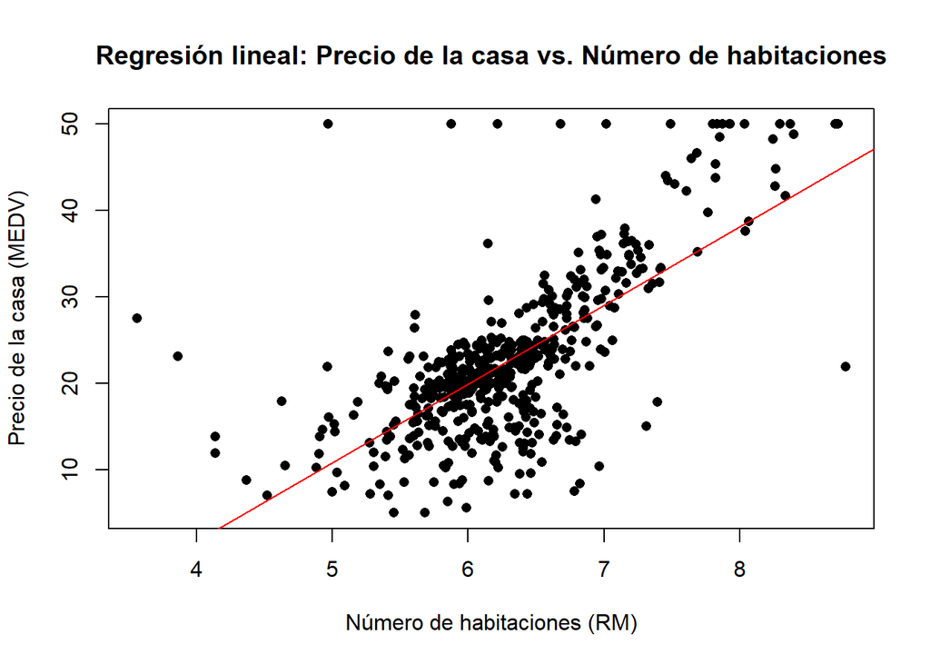

```r
# Visualización de los datos y la línea de regresión
plot(Boston$rm, Boston$medv, main = "Regresión lineal: Precio de la casa vs. Número de habitaciones",
     xlab = "Número de habitaciones (RM)", ylab = "Precio de la casa (MEDV)", pch = 16)
abline(modelo_regresion, col = "red")
```

# 11 Compare los resultados del modelo de regresión generado con los de hojas anteriores que utilicen la misma variable, como la de regresión lineal

```r
# Especificar un repositorio CRAN
cran_repo <- "https://cloud.r-project.org/"

# Instalar y cargar las bibliotecas necesarias
install.packages(c("tidyverse", "caret", "Metrics"), repos = cran_repo)
library(tidyverse)
library(caret)
library(Metrics)
# Leer el archivo train.csv
train_data <- read_csv("train.csv")
# Dividir el conjunto de datos en entrenamiento y prueba
set.seed(123)
train_index <- createDataPartition(train_data$SalePrice, p = 0.8, list = FALSE)
train_set <- train_data[train_index, ]
test_set <- train_data[-train_index, ]

# Modelo de regresión lineal simple utilizando GrLivArea
modelo_simple <- lm(SalePrice ~ GrLivArea, data = train_set)

# Modelo de regresión lineal múltiple con más variables
modelo_multiple <- lm(SalePrice ~ GrLivArea + OverallQual + YearBuilt + LotArea + TotalBsmtSF, data = train_set)

# Predecir los precios de venta en el conjunto de prueba
predicciones_simple <- predict(modelo_simple, newdata = test_set)
predicciones_multiple <- predict(modelo_multiple, newdata = test_set)

# Calcular el RMSE para ambos modelos
rmse_simple <- rmse(test_set$SalePrice, predicciones_simple)
rmse_multiple <- rmse(test_set$SalePrice, predicciones_multiple)

# Comparar los resultados
cat("RMSE del modelo simple: ", rmse_simple, "\n")
```

```
## RMSE del modelo simple:  62153.54
```

```r
cat("RMSE del modelo múltiple: ", rmse_multiple, "\n")
```

```
## RMSE del modelo múltiple:  46525.38
```

# 12 Genere un informe de los resultados y las explicaciones

###Resumen de los modelos:

Modelo simple: Regresión lineal simple utilizando solo la variable GrLivArea para predecir SalePrice. Modelo múltiple: Regresión lineal múltiple utilizando las variables GrLivArea, OverallQual, YearBuilt, LotArea y TotalBsmtSF para predecir SalePrice. Resultados:

RMSE del modelo simple: 62,153.54 RMSE del modelo múltiple: 46,525.38

### Análisis de los resultados:

El modelo de regresión lineal simple utiliza solo la variable GrLivArea, que representa el área habitable por encima del nivel del suelo en pies cuadrados. Por otro lado, el modelo de regresión lineal múltiple utiliza cinco variables para predecir el precio de venta de una casa, incorporando información adicional sobre la calidad general, el año de construcción, el área del lote y el área del sótano total.

El RMSE (Root Mean Squared Error) es una medida común de la precisión de un modelo de regresión. Cuanto menor sea el RMSE, mejor será el rendimiento del modelo en términos de precisión de las predicciones. En este caso, se puede observar que el RMSE del modelo múltiple es significativamente menor que el RMSE del modelo simple. Esto indica que el modelo múltiple es más preciso en sus predicciones que el modelo simple.

#### Conclusiones:

Basándonos en los resultados, podemos concluir que el modelo de regresión lineal múltiple con las cinco variables (GrLivArea, OverallQual, YearBuilt, LotArea y TotalBsmtSF) es más preciso para predecir el precio de venta de una casa en comparación con el modelo de regresión lineal simple que solo utiliza la variable GrLivArea. Esto sugiere que incluir más variables relevantes en el modelo puede mejorar su capacidad para predecir con precisión el precio de venta de una casa.